### 0. О том, как выполнять это домашнее задание.

Это задание написано в формате R Markdown (.Rmd). Чтобы облегчить его проверку, мы просим вас писать код в блоки для кода на R, например,

```r
# YOUR CODE HERE
# (хештеги используются для комментариев, убирайте хештеги в начале строки, чтобы ваш код запускался)
```

и текст в блоки для текста. Пожалуйста, впишите ниже ваше имя и фамилию:

```
Мое имя: Артамонова Ксения
```

Перед сдачей домашнего задания рекомендуем запустить `Run All` или сгенерировать html- или pdf-страницу с помощью `Knit`, чтобы убедиться, что в финальной версии весь ваш код будет запускаться без проблем.

Файл Rmd (`HW1.Rmd`) и сгенерированный из него html (вариант - pdf) вышлите на почту `neurolong@gmail.com` с темой `da4cl`.

## 1. Частотность и фонетика

Во многих лингвистических исследованиях отмечается, что часто используемые в языке слова звучат короче, а при их произнесении наблюдается редукция и коартикуляция. Работа [Fabian Tomaschek et al.](https://www.semanticscholar.org/paper/Practice-makes-perfect-%3A-The-consequences-of-for-Tomaschek-Tucker/1e0dbc3787a6da84ffd4c3cae62f1340e4267694) (2018) исследует гипотезу, что моторные навыки произнесения улучшаются с опытом, который, в свою очередь, напрямую связан с частотностью слова. Ученые попросили испытуемых (17 бакалавров университета Тюбингена, 8 мужчин и 9 женщин) прочитать вслух немецкие глаголы, содержащие звук [a:] в основе. Испытуемые были поставлены в экспериментальные условия, которые исподволь заставляли их читать быстрее или медленнее (slow/fast condition).

В этом задании мы просим вас в графическом виде показать распределение в датасете длины звучания всего слова целиком, а также распределение длины звучания интересующего ученых сегмента (звука [a:]) в условиях slow и fast. Хотя логично предположить, что в условии fast произнесение и слов, и сегментов будет короче, все же нужно убедиться, что данные это подтверждают, прежде чем переходить к более сложному анализу по сути вопроса. Кроме того, мы будем уверены, что экспериментальные условия были должным образом соблюдены, ученые не запутались в кодировании данных и документировали результаты корректно.

**Интересующие нас переменные:**

- `LogDurationW` - log-transformed word duration (логарифм длины произнесения слова)
- `LogDurationA` - log-transformed segment duration (логарифм длины произнесения сегмента)
- `Cond` - condition: slow vs. fast (условие).

### 1.1 Загрузка данных

Загрузите пакеты `tidyverse` и `skimr`.  
С помощью функции `read_csv` загрузите данные ([link](https://raw.githubusercontent.com/LingData2019/LingData2020/master/data/dur_word_frequency.csv)) в переменную `dur_word_freq`.  
Используйте функции `summary()`, `glimpse()` и `skim()` (последняя из пакета `skimr`), чтобы изучить структуру данных.

```r
install.packages("skimr")
```

[output not shown]

```r
install.packages("tidyverse")
```

[output not shown]

```r
library(tidyverse)
library(skimr)
dur_word_freq <- read_csv("https://raw.githubusercontent.com/LingData2019/LingData2020/master/data/dur_word_frequency.csv")
```

```
## ──────────────────────────────────────────────────────── Delimiter: "," chr
## (4): Lemma, Participant, Cond, Exponent dbl (4): ...1, LogDurationA,
## LogDurationW, Frequency
```

```r
str(dur_word_freq)
```

```
## spc_tbl_ [832 × 8] (S3: spec_tbl_df/tbl_df/tbl/data.frame)
##  $ ...1        : num [1:832] 11431 1 136 71 11581 ...
##  $ LogDurationA: num [1:832] -1.32 -1.36 -1.5 -1.28 -1.33 ...
##  $ LogDurationW: num [1:832] -0.477 -0.36 -0.27 -0.377 -0.447 ...
##  $ Lemma       : chr [1:832] "schab" "blas" "schlaf" "lahm" ...
##  $ Participant : chr [1:832] "Art_02_S01" "Art_02_S01" "Art_02_S01" "Art_02_S01" ...
##  $ Cond        : chr [1:832] "slow" "slow" "slow" "slow" ...
##  $ Exponent    : chr [1:832] "t" "n" "en" "en" ...
##  $ Frequency   : num [1:832] -6.98 -5.74 -4.68 -6.26 -6.47 ...
##  - attr(*, "spec")=
##   .. cols(
##   ..   ...1 = col_double(),
##   ..   LogDurationA = col_double(),
##   ..   LogDurationW = col_double(),
##   ..   Lemma = col_character(),
##   ..   Participant = col_character(),
##   ..   Cond = col_character(),
##   ..   Exponent = col_character(),
##   ..   Frequency = col_double()
##   .. )
##  - attr(*, "problems")=<externalptr>
```

```r
summary(dur_word_freq)
```

```
##       ...1           LogDurationA     LogDurationW        Lemma
##  Min.   :       1   Min.   :-3.507   Min.   :-1.2378   Length:832
##  1st Qu.:    3949   1st Qu.:-1.811   1st Qu.:-0.6330   Class :character
##  Median :    7948   Median :-1.670   Median :-0.5108   Mode  :character
##  Mean   :  451082   Mean   :-1.681   Mean   :-0.5130
##  3rd Qu.:  541999   3rd Qu.:-1.534   3rd Qu.:-0.4005
##  Max.   :16981104   Max.   :-1.097   Max.   : 0.5787
##  Participant            Cond             Exponent           Frequency
##  Length:832         Length:832         Length:832         Min.   :-7.598
##  Class :character   Class :character   Class :character   1st Qu.:-6.759
##  Mode  :character   Mode  :character   Mode  :character   Median :-6.203
##                                                           Mean   :-6.170
##                                                           3rd Qu.:-5.741
##                                                           Max.   :-4.275
```

```r
glimpse(dur_word_freq)
```

```
## Rows: 832
## Columns: 8
## $ ...1         <dbl> 11431, 1, 136, 71, 11581, 33, 100, 16957, 127, 163, 218, …
## $ LogDurationA <dbl> -1.324496, -1.357757, -1.496422, -1.284340, -1.331510, -1…
## $ LogDurationW <dbl> -0.4768593, -0.3595504, -0.2701372, -0.3773472, -0.447127…
## $ Lemma        <chr> "schab", "blas", "schlaf", "lahm", "lahm", "fahnd", "mahn…
## $ Participant  <chr> "Art_02_S01", "Art_02_S01", "Art_02_S01", "Art_02_S01", "…
## $ Cond         <chr> "slow", "slow", "slow", "slow", "slow", "slow", "slow", "…
## $ Exponent     <chr> "t", "n", "en", "en", "t", "en", "en", "t", "n", "n", "n"…
## $ Frequency    <dbl> -6.980044, -5.740760, -4.676302, -6.263638, -6.469370, -6…
```

### 1.2 Типы данных

Какие базовые типы переменных (строковые, числовые (непрерывные), целочисленные, логические, комплексные) представляют данные в столбцах `dur_word_freq`?

[output not shown]

[output not shown]

```r
str(dur_word_freq)
```

```
## spc_tbl_ [832 × 8] (S3: spec_tbl_df/tbl_df/tbl/data.frame)
##  $ ...1        : num [1:832] 11431 1 136 71 11581 ...
##  $ LogDurationA: num [1:832] -1.32 -1.36 -1.5 -1.28 -1.33 ...
##  $ LogDurationW: num [1:832] -0.477 -0.36 -0.27 -0.377 -0.447 ...
##  $ Lemma       : chr [1:832] "schab" "blas" "schlaf" "lahm" ...
##  $ Participant : chr [1:832] "Art_02_S01" "Art_02_S01" "Art_02_S01" "Art_02_S01" ...
##  $ Cond        : chr [1:832] "slow" "slow" "slow" "slow" ...
##  $ Exponent    : chr [1:832] "t" "n" "en" "en" ...
##  $ Frequency   : num [1:832] -6.98 -5.74 -4.68 -6.26 -6.47 ...
##  - attr(*, "spec")=
##   .. cols(
##   ..   ...1 = col_double(),
##   ..   LogDurationA = col_double(),
##   ..   LogDurationW = col_double(),
##   ..   Lemma = col_character(),
##   ..   Participant = col_character(),
##   ..   Cond = col_character(),
##   ..   Exponent = col_character(),
##   ..   Frequency = col_double()
##   .. )
##  - attr(*, "problems")=<externalptr>
```

```
Ответ:
LogDurationA, LogDurationW,Frequency - числовые;
Lemma, Participant,Cond, Exponent - строковые
```

### 1.3 Визуализации ggplot: график плотности (density plot)

О графике плотности распределения можно думать как о сглаженной гистограмме с большим числом столбцов. Общая площадь под графиком составляет 1. Раскомментируйте и запустите следующий код, который позволяет представить распределение непрерывных значений переменной `LogDurationA`, сгруппированных по переменной `Cond` (т. е. длина звука а в условиях fast и slow).

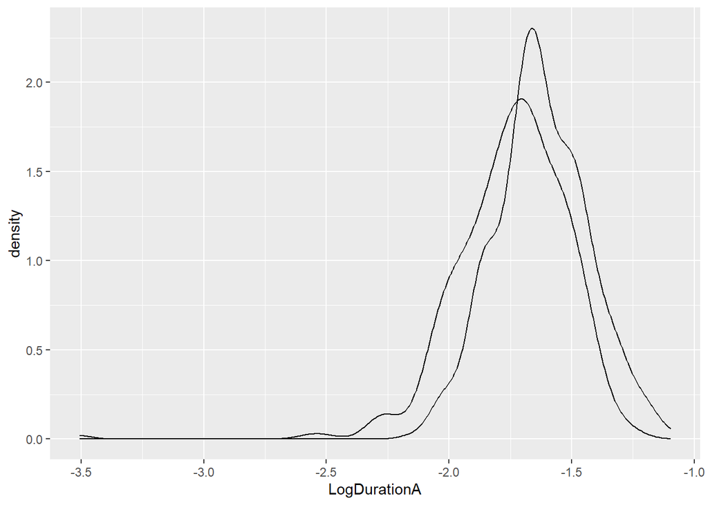

```r
dur_word_freq |>
  ggplot(aes(x = LogDurationA, group = Cond)) +
  geom_density()
```

### 1.4

Добавьте в график тему `theme_classic()` и полупрозрачность (alpha = 0.5, указывается в геоме плотности).

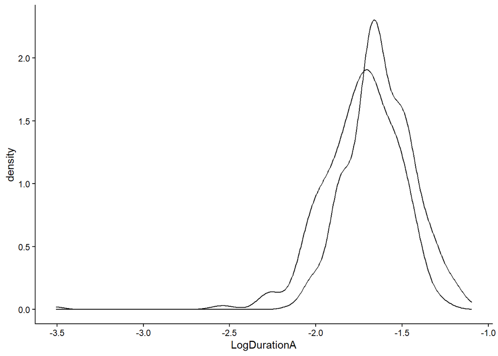

```r
dur_word_freq |>
  ggplot(aes(x = LogDurationA, group = Cond)) +
  geom_density(alpha = 0.5) +
  theme_classic()
```

### 1.5

Постройте график плотности распределения длины всего слова (переменная `LogDurationW`) для всех данных (без деления по условиям).

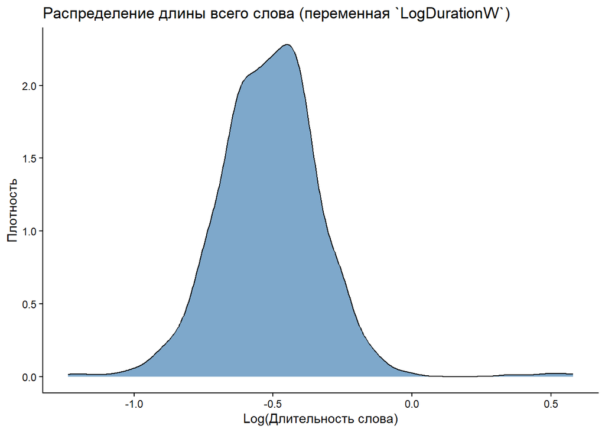

```r
dur_word_freq |>
  ggplot(aes(x = LogDurationW)) +
  geom_density(fill = "steelblue", alpha = 0.7) +
  theme_classic() +
  labs(title = "Распределение длины всего слова (переменная `LogDurationW`)",
       x = "Log(Длительность слова)",
       y = "Плотность")
```

### 1.6 Боксплот (базовый R)

Раскомментируйте и запустите следующий код.

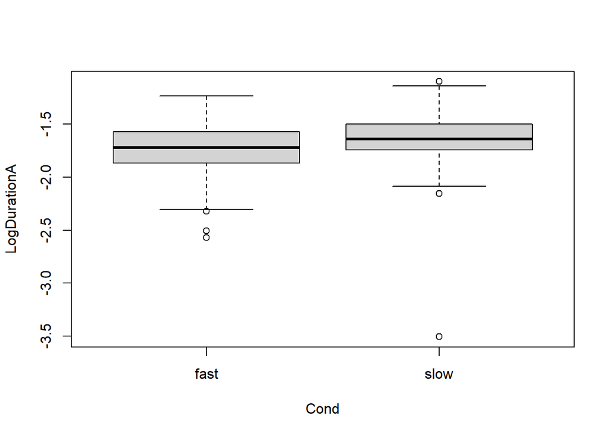

```r
 boxplot(LogDurationA ~ Cond, data=dur_word_freq)
```

Результатом будут так называемые “ящики с усами” (*box and whisker plot*) для значений переменной `LogDurationA`, сгруппированным по переменной `Cond`. Больше об этом типе визуализаций можно прочесть в [Википедии](https://ru.wikipedia.org/wiki/%D0%AF%D1%89%D0%B8%D0%BA_%D1%81_%D1%83%D1%81%D0%B0%D0%BC%D0%B8) (или [Английской Википедии](https://en.wikipedia.org/wiki/Box_plot).

### 1.7

Сравните положение медианных значений `LogDurationA`, а также значений 1-го и 3-го квартиля в условиях fast и slow, запишите кратко ваши выводы ниже (2-3 предложения).

```
# 1.7
Сравнение распределений LogDurationA в условиях fast и slow:
1)  1-й квартиль (нижняя граница ящика) и 3-й квартиль (верхняя граница ящика) расположены ниже в условии fast по сравнению с slow, что указывает на сокращение длительности сегмента при ускорении речи.
2) Медиана также ниже в условиях fast, поэтому можно понять что этот сегмент А сокращается в произношении при ускорении речи.
```

### 1.8. Боксплот в ggplot2

Для переменной `LogDurationW` представим боксплоты в условиях fast и slow с помощью пакета `ggplot2` (геом `geom_boxplot`). По оси X у вас будут заданы два боксплота (задаются переменной `Cond`). По оси Y будет представлено распределение длин в переменной `LogDurationW`. Заливка должна зависеть от условия (переменной `Cond`). Все эти три аргумента задаются в базовой эстетике ggplot.  
Измените (сделайте более понятными) подписи осей X и Y, добавьте тему `theme_classic()`.

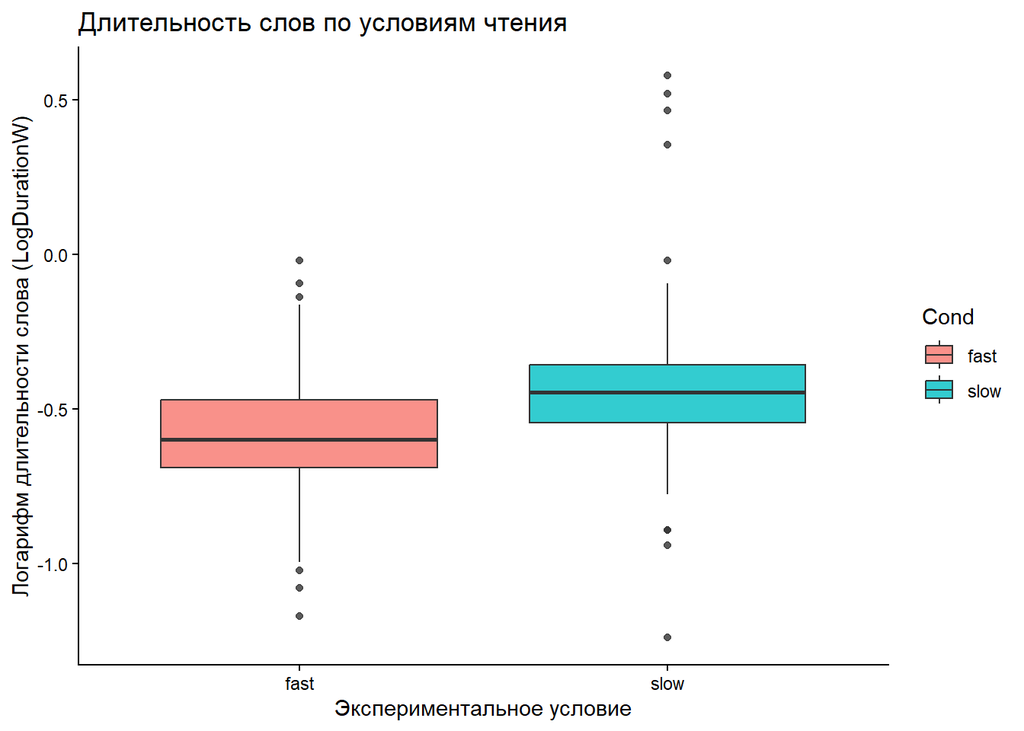

```r
dur_word_freq |>
  ggplot(aes(x = Cond, y = LogDurationW, fill = Cond)) +
  geom_boxplot(alpha = 0.8) +
  theme_classic() +
  labs(title = "Длительность слов по условиям чтения",
       x = "Экспериментальное условие",
       y = "Логарифм длительности слова (LogDurationW)")
```

Необязательное задание - измените цвет заполнения боксплотов с помощью `scale_fill_brewer` из пакета `RColorBrewer` (палитра Dark2).

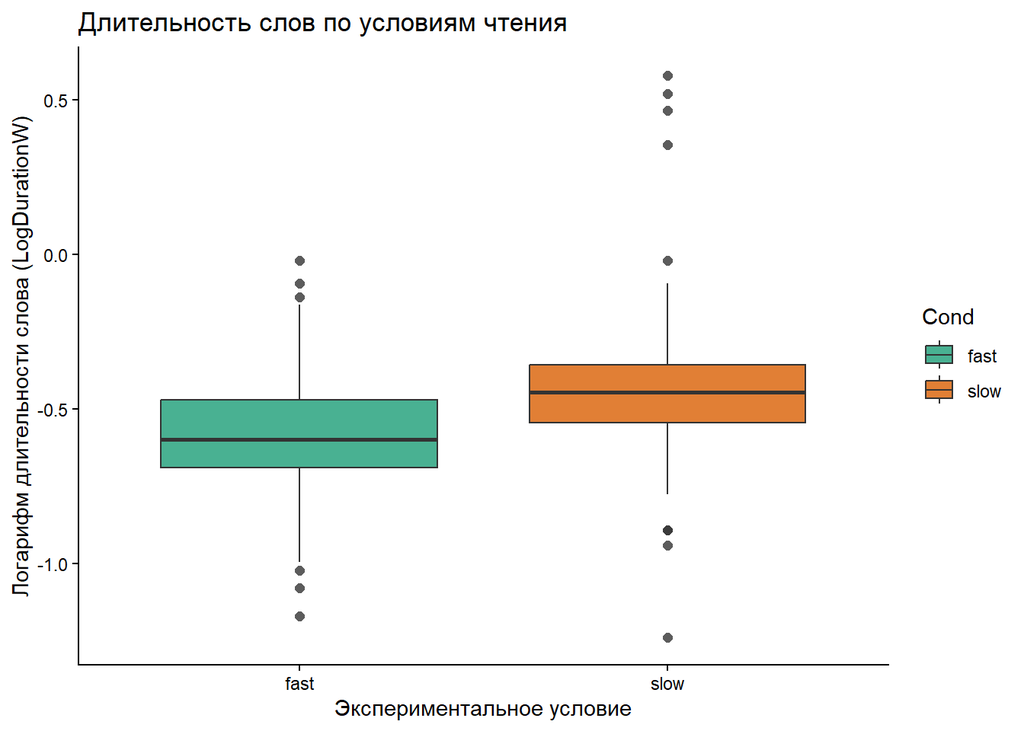

```r
dur_word_freq |>
  ggplot(aes(x = Cond, y = LogDurationW, fill = Cond)) +
  geom_boxplot(alpha = 0.8, outlier.shape = 16, outlier.size = 2) +
  theme_classic() +
  labs(title = "Длительность слов по условиям чтения",
       x = "Экспериментальное условие",
       y = "Логарифм длительности слова (LogDurationW)") +
  scale_fill_brewer(palette = "Dark2")
```

### 1.9 Скрипичный плот в ggplot2

С помощью ggplot2 постройте скрипичные графики (violin plot, геом `geom_violin`) для переменной `LogDurationA` в двух условиях fast и slow.

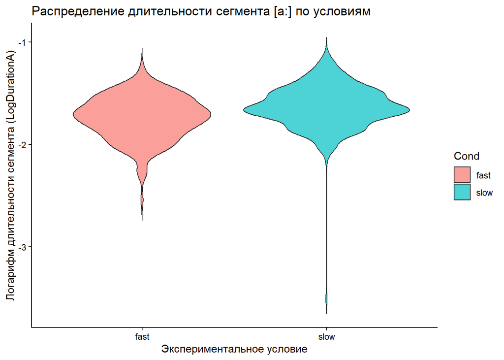

```r
dur_word_freq |>
  ggplot(aes(x = Cond, y = LogDurationA, fill = Cond)) +
  geom_violin(alpha = 0.7, trim = FALSE) +
  theme_classic() +
  labs(title = "Распределение длительности сегмента [a:] по условиям",
       x = "Экспериментальное условие",
       y = "Логарифм длительности сегмента (LogDurationA)")
```

### 1.10 Jitter

К предыдущему графику 1.9 новым слоем добавьте конкретные точки из вашего датасета, при этом используйте jitter (геом `geom_jitter`), чтобы немного развести точки в стороны.

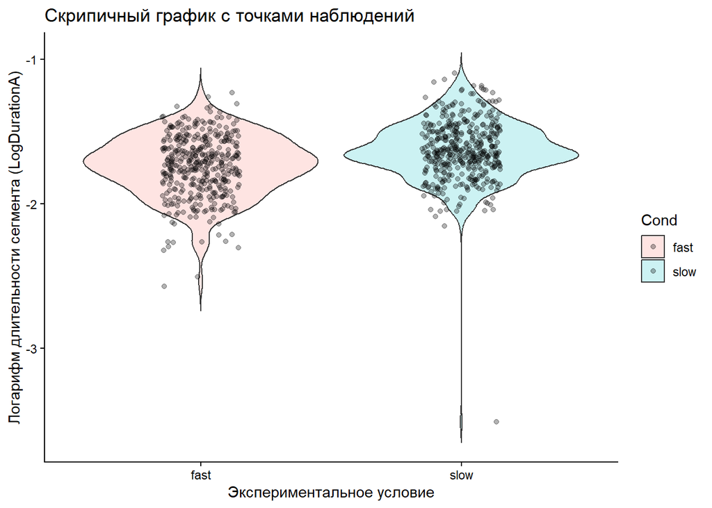

```r
dur_word_freq |>
  ggplot(aes(x = Cond, y = LogDurationA, fill = Cond)) +
  geom_violin(alpha = 0.2, trim = FALSE, scale = "width") +
  geom_jitter(width = 0.15, height = 0, alpha = 0.3, size = 1.5, color = "black") +
  theme_classic() +
  labs(title = "Скрипичный график с точками наблюдений",
       x = "Экспериментальное условие",
       y = "Логарифм длительности сегмента (LogDurationA)")
```

### 1.11. Скаттерплот в ggplot2

Постройте диаграмму рассеяния (= точечную диаграмму = скаттерплот, геом `geom_point`) для переменных `LogDurationA` (по оси X) и `LogDurationW` (по оси Y). Используйте прозрачность 0.3. Добавьте на график регрессионную прямую (метод “lm”).

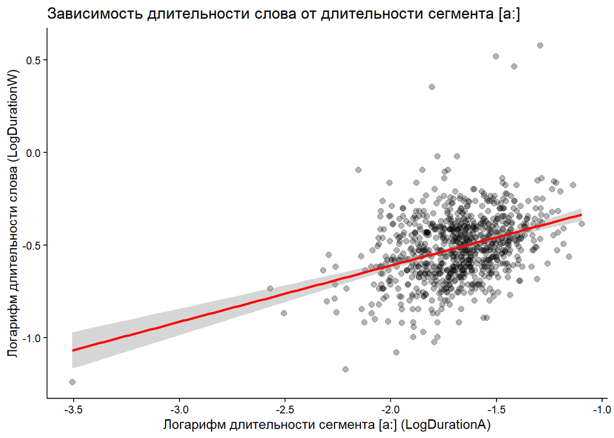

```r
dur_word_freq |>
  ggplot(aes(x = LogDurationA, y = LogDurationW)) +
  geom_point(alpha = 0.3, size = 2) +
  geom_smooth(method = "lm", se = TRUE, color = "red", linewidth = 1, formula = y ~ x) +
  theme_classic() +
  labs(title = "Зависимость длительности слова от длительности сегмента [a:]",
       x = "Логарифм длительности сегмента [a:] (LogDurationA)",
       y = "Логарифм длительности слова (LogDurationW)")
```